# HW_03

RChandra

2025-12-16

## Homework 3 - Principal Component Analysis Section

*Background:* The CDC Social Vulnerability Index (SVI) takes multiple different population-level inputs (e.g., % of the population living in poverty, % of the population without health insurance) to identify particularly vulnerable counties. While the CDC SVI scores rely on adding up the percentiles of various characteristics, there are alternative indexes (e.g., [University of South Carolina SoVI index](https://sc.edu/study/colleges_schools/artsandsciences/centers_and_institutes/hvri/data_and_resources/sovi/index.php)) that use methods like PCA. Here, we are going to use the CDC SVI data to create an alternative index based on PCA.

**Step One:** Load the data

```r
library(readr)
merged_NRI_SVI <- read_csv("data/processed/merged_NRI_SVI.csv")
View(merged_NRI_SVI)
```

**Step Two:** Separate out the variables listed in the question and create a new dataset out of them.

```r
svi_vars <- c("EP_POV150", "EP_UNEMP", "EP_HBURD", "EP_NOHSDP", "EP_UNINSUR",
              "EP_AGE65", "EP_AGE17", "EP_DISABL", "EP_SNGPNT", "EP_LIMENG",
              "EP_MINRTY", "EP_MUNIT", "EP_MOBILE", "EP_CROWD", "EP_NOVEH",
              "EP_GROUPQ", "EP_NOINT")
  svi_data_complete <- merged_NRI_SVI[rowSums(is.na(merged_NRI_SVI[, svi_vars])) != length(svi_vars), ]
  svi_numeric <- svi_data_complete[, svi_vars]
  removed_rows <- nrow(merged_NRI_SVI) - nrow(svi_data_complete)
  cat("Number of rows removed:", removed_rows, "\n")
```

```
## Number of rows removed: 96
```

**Step Three:** Perform Principal Component analysis using prcomp() and standardize the variables to have mean 0 and a standard deviation of 1.

```r
svi_pca <- prcomp(svi_numeric, center = TRUE, scale. = TRUE)
```

Summarize:

```r
summary(svi_pca)
```

```
## Importance of components:
##                           PC1    PC2    PC3     PC4     PC5    PC6     PC7
## Standard deviation     2.1905 1.8053 1.3567 1.07542 1.00395 0.9861 0.78714
## Proportion of Variance 0.2823 0.1917 0.1083 0.06803 0.05929 0.0572 0.03645
## Cumulative Proportion  0.2823 0.4740 0.5822 0.65028 0.70956 0.7668 0.80321
##                            PC8     PC9    PC10    PC11    PC12    PC13    PC14
## Standard deviation     0.76311 0.70845 0.66805 0.64659 0.60284 0.53770 0.49566
## Proportion of Variance 0.03426 0.02952 0.02625 0.02459 0.02138 0.01701 0.01445
## Cumulative Proportion  0.83747 0.86699 0.89324 0.91784 0.93921 0.95622 0.97067
##                           PC15    PC16    PC17
## Standard deviation     0.44428 0.39889 0.37690
## Proportion of Variance 0.01161 0.00936 0.00836
## Cumulative Proportion  0.98228 0.99164 1.00000
```

View the loadings:

```r
svi_pca$rotation
```

```
##                    PC1          PC2         PC3           PC4          PC5
## EP_POV150   0.36755470  0.188617523 -0.10807066  0.1194476630  0.053983643
## EP_UNEMP    0.27810755  0.043502103 -0.27015268  0.2699377070 -0.084604245
## EP_HBURD    0.13855430 -0.169401996 -0.46036267  0.0004925602  0.015237863
## EP_NOHSDP   0.36842756  0.092792276  0.13989605 -0.2290324706 -0.005784969
## EP_UNINSUR  0.29265168 -0.003919953  0.28101967 -0.2075103829 -0.102270338
## EP_AGE65   -0.14497246  0.374995461 -0.09892695 -0.1272553268 -0.473703294
## EP_AGE17    0.14154244 -0.249302191  0.46805303  0.3845859678  0.104274664
## EP_DISABL   0.15452899  0.411806724 -0.13904294  0.0915040044 -0.079976342
## EP_SNGPNT   0.29952157 -0.145346262 -0.06646182  0.2626224080  0.364311819
## EP_LIMENG   0.17896245 -0.273168506  0.15752765 -0.4961454790 -0.279674574
## EP_MINRTY   0.33362274 -0.224517100 -0.03610698 -0.1771289621 -0.019527652
## EP_MUNIT   -0.04540515 -0.382089141 -0.34948297 -0.0769138251 -0.165062881
## EP_MOBILE   0.23603979  0.317912002  0.11274009 -0.0726402334  0.070136629
## EP_CROWD    0.25262017 -0.219097511  0.12127538  0.0608143869 -0.346938574
## EP_NOVEH    0.22041992 -0.099840196 -0.31786019  0.2249776364 -0.314258277
## EP_GROUPQ   0.09492841  0.038936516 -0.27095372 -0.4824470052  0.523695000
## EP_NOINT    0.26422245  0.316461289  0.04609921  0.0104706377 -0.025893712
##                     PC6          PC7          PC8          PC9         PC10
## EP_POV150   0.098786352 -0.171597595 -0.052564581  0.097573664 -0.140215352
## EP_UNEMP    0.002535016  0.637856224  0.138662330 -0.162317043  0.075837584
## EP_HBURD    0.483361663 -0.153865347  0.199259961  0.213505528 -0.345508849
## EP_NOHSDP   0.094784228  0.008767144 -0.420099113  0.005106053 -0.111810756
## EP_UNINSUR  0.034454675 -0.248385333  0.565933716  0.193305993 -0.178173054
## EP_AGE65    0.091302186 -0.073506684  0.197810747 -0.358385310 -0.004416933
## EP_AGE17   -0.010287579 -0.083221374 -0.143645895  0.036394888 -0.169825678
## EP_DISABL   0.104813583  0.073208148 -0.290248047  0.060290707 -0.349397706
## EP_SNGPNT   0.173036355 -0.103179075  0.022498272 -0.404897257  0.119152678
## EP_LIMENG   0.187622161  0.127773876 -0.359969010 -0.200725599 -0.057318115
## EP_MINRTY   0.106104971  0.039347044  0.208872974 -0.297141950  0.354236908
## EP_MUNIT    0.043471699 -0.191070866 -0.159974896  0.327285358  0.325729080
## EP_MOBILE   0.102195109  0.240027877 -0.002036065  0.547662944  0.487289209
## EP_CROWD   -0.382712522  0.254760687  0.220190334  0.146801738 -0.225872286
## EP_NOVEH   -0.480061912 -0.264250372 -0.214803356  0.020873351  0.030270352
## EP_GROUPQ  -0.481703110  0.075405523  0.058491413 -0.031763470 -0.203156187
## EP_NOINT   -0.171159571 -0.444409235  0.013430896 -0.158692837  0.283375900
##                   PC11        PC12        PC13          PC14         PC15
## EP_POV150  -0.03515435 -0.23211723 -0.18697085 -0.3639418086 -0.553165672
## EP_UNEMP   -0.50078851 -0.09642001  0.05878849 -0.1236067376  0.061171393
## EP_HBURD    0.18461832 -0.33102299  0.19233475  0.1598121380  0.156142590
```

[output cut: 17 more lines]

```
## EP_HBURD    0.12837257  0.175807145
## EP_NOHSDP  -0.61110151  0.290486033
## EP_UNINSUR  0.07507337 -0.021660396
## EP_AGE65   -0.00621897  0.465892272
## EP_AGE17    0.23474853  0.503479398
## EP_DISABL   0.13115976 -0.004292424
## EP_SNGPNT   0.07834841  0.055935367
## EP_LIMENG   0.51134430 -0.189077209
## EP_MINRTY  -0.25029352 -0.075297317
## EP_MUNIT   -0.08534180  0.283722658
## EP_MOBILE   0.22464391  0.119262850
## EP_CROWD   -0.16393161 -0.004966043
## EP_NOVEH    0.13480926 -0.078941223
## EP_GROUPQ   0.14020025  0.260294084
## EP_NOINT    0.21715016  0.069432560
```

# Plotting the loadings

**Step One:** load the following packages:

```r
library(ggplot2)
library(tidyr)
library(dplyr)
```

**Step Two:** Next, extract the eigenvectors

```r
loadings_df <- as.data.frame(svi_pca$rotation[, 1:3])
loadings_df$Variable <- rownames(loadings_df)
```

**Step Three:** Lastly, reshape the eigenvectors for plotting and plot the first three Principal Components.

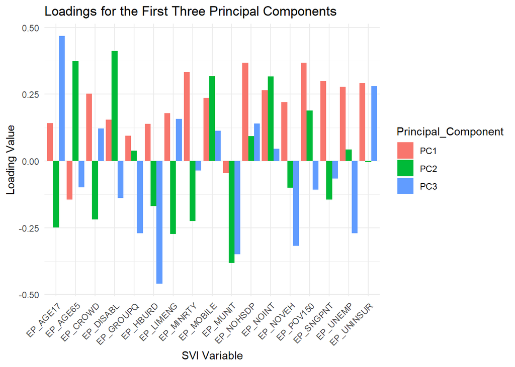

```r
loadings_long <- loadings_df %>%
  pivot_longer(cols = starts_with("PC"),
               names_to = "Principal_Component",
               values_to = "Loading")
ggplot(loadings_long, aes(x = Variable, y = Loading, fill = Principal_Component)) +
  geom_bar(stat = "identity", position = "dodge") +
  theme_minimal() +
  theme(axis.text.x = element_text(angle = 45, hjust = 1)) +
  labs(title = "Loadings for the First Three Principal Components",
       x = "SVI Variable",
       y = "Loading Value")
```

**My Description:** The loadings plot shows that the first principal component (PC1) is dominated by variables related to socioeconomic disadvantage (e.g., poverty, unemployment, minority status, and single-parent households). This component can be interpreted as a general measure of social vulnerability. The second component (PC2) contrasts areas with higher disability and mobile-home populations against those with more multi-unit housing and younger populations, suggesting a rural–urban dimension.Lastly, the third component (PC3) appears to capture variation related to family and household composition, distinguishing areas with more children and uninsured individuals from those with higher housing burden and group quarters populations.

# Determining the minimum number of Principal Components needed:

People often use PCA in downstream analyses (e.g., regression).When doing this, they need to choose the number of principal components to use in the analysis. There are several different ways to determine the number of principal components to retain. One common method is to retain principal components that explain a certain percentage of the variance in the data.

**Step One:** Create string variables for the proportion of variance explained by each component and the cumulative proportion of variance explained by the components.

```r
var_explained <- summary(svi_pca)$importance[2, ]
cum_var_explained <- summary(svi_pca)$importance[3, ]
```

**Step Two:** Find how many PCs are needed to reach 80% and 90% variance.

```r
pc_80 <- min(which(cum_var_explained >= 0.80))
pc_90 <- min(which(cum_var_explained >= 0.90))
cat("Number of PCs to explain at least 80% variance:", pc_80, "\n")
```

```
## Number of PCs to explain at least 80% variance: 7
```

```r
cat("Number of PCs to explain at least 90% variance:", pc_90, "\n")
```

```
## Number of PCs to explain at least 90% variance: 11
```

1. How many principal components are needed to explain 80% of the variance in the data? *My Answer:* At least 7.
2. How many principal components are needed to explain 90% of the variance in the data? *My Answer:* At least 11.

# Scree Plot

An alternative approach is to plot the eigenvalues of the principal components and retain the components that are above the “elbow” in the plot. In other words the eigenvalues that are substantially larger than the rest. **Step One:** Create a [scree plot](https://en.wikipedia.org/wiki/Scree_plot) of the eigenvalues of the principal components.

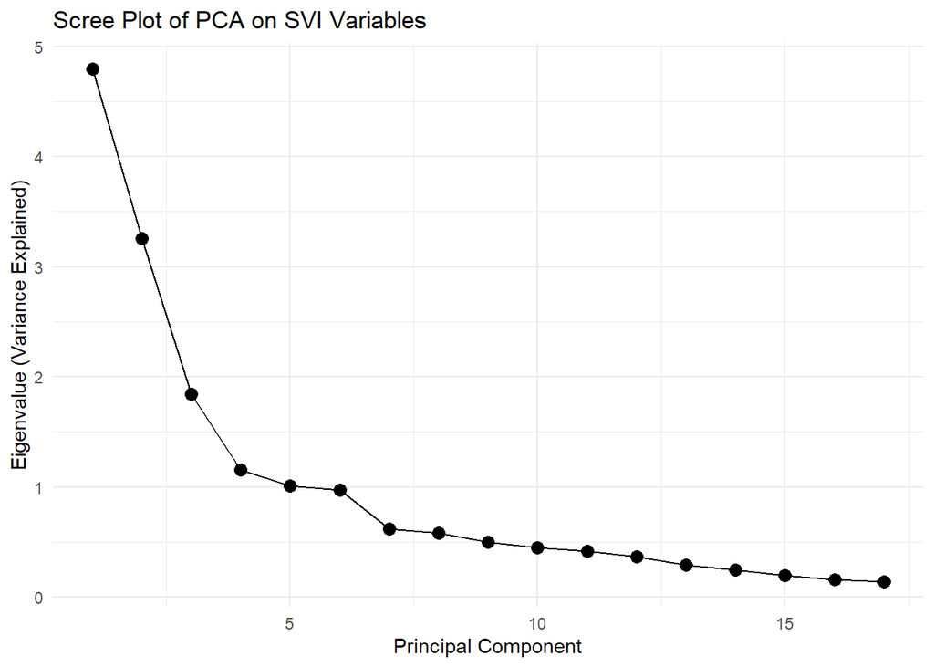

```r
library(ggplot2)
eigenvalues <- svi_pca$sdev^2
scree_df <- data.frame(
  PC = 1:length(eigenvalues),
  Eigenvalue = eigenvalues
)
# The Plot
ggplot(scree_df, aes(x = PC, y = Eigenvalue)) +
  geom_point(size = 3) +
  geom_line() +
  theme_minimal() +
  labs(title = "Scree Plot of PCA on SVI Variables",
       x = "Principal Component",
       y = "Eigenvalue (Variance Explained)")
```

**Step Two:** Plot the first principal component score on a map of the US counties.(First re-attach the missing identifying variables)

```r
svi_data_complete$FIPS <- sprintf("%05d", as.numeric(svi_data_complete$STCOFIPS))
head(svi_data_complete$FIPS)
```

```
## [1] "01001" "01003" "01005" "01007" "01009" "01011"
```

```r
pca_scores <- as.data.frame(svi_pca$x)
pca_scores$FIPS <- svi_data_complete$FIPS
```

**Step Three:** Load county boundaries packages

```r
library(tigris)
library(sf)
```

```r
library(dplyr)
library(ggplot2)
```

**Step Four:** Load county shapefile and set cb = TRUE for simplified boundaries.

```r
counties_sf <- counties(cb = TRUE, year = 2022)
```

[output not shown]

**Step Five:** Join PCA scores to county shapefile by FIPS/GEOID

```r
counties_pca <- counties_sf %>%
  left_join(pca_scores, by = c("GEOID" = "FIPS"))
```

# The Plot

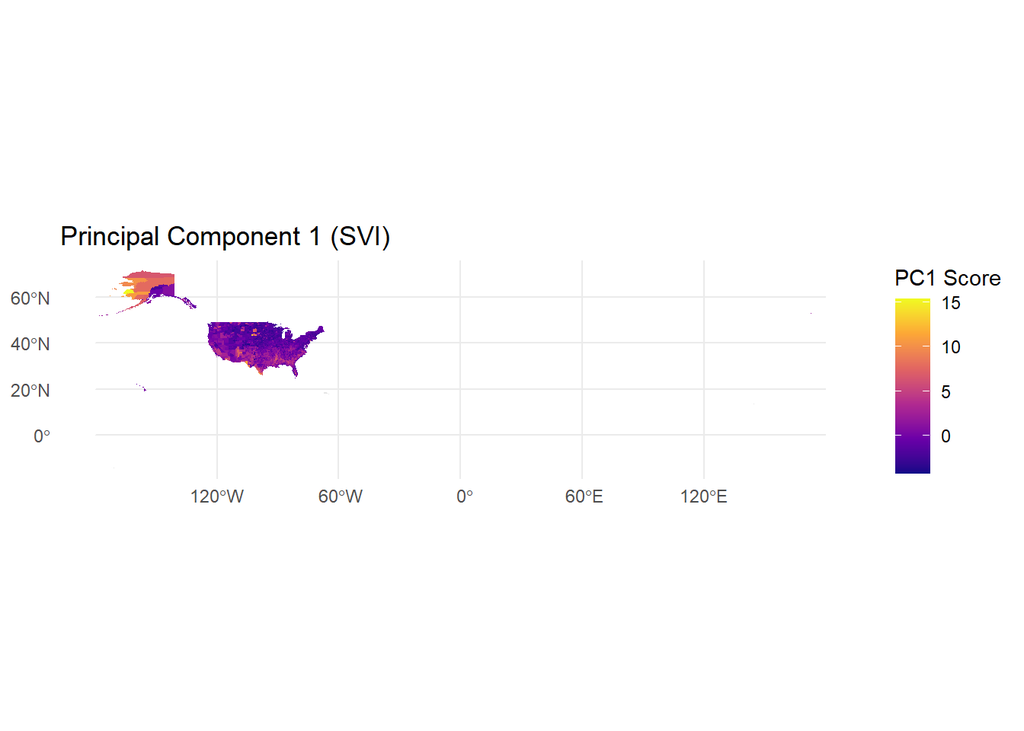

```r
ggplot(counties_pca) +
  geom_sf(aes(fill = PC1), color = NA) +
  scale_fill_viridis_c(option = "plasma", na.value = "grey90") +
  labs(title = "Principal Component 1 (SVI)",
       fill = "PC1 Score") +
  theme_minimal()
```

```r
library(parallel)
set.seed(1234)
```

```r
pca_cv_error <- function(data, k, nfolds = 5) {
  data <- as.matrix(data)  # ensure numeric matrix
  n <- nrow(data)
  fold_ids <- sample(rep(1:nfolds, length.out = n))
  errors <- numeric(nfolds)

  for (fold in 1:nfolds) {
    train <- data[fold_ids != fold, , drop = FALSE]
    test  <- data[fold_ids == fold, , drop = FALSE]

    # Fit PCA on training data
    pca_train <- prcomp(train, center = TRUE, scale. = TRUE)

    # Center and scale test data using training parameters
    test_centered <- scale(test, center = pca_train$center, scale = pca_train$scale)

    # Project test data onto first k components
    test_proj <- test_centered %*% pca_train$rotation[, 1:k]

    # Reconstruct test data from k components
    test_recon <- test_proj %*% t(pca_train$rotation[, 1:k])
    test_recon <- sweep(test_recon, 2, pca_train$center, "+")

    # Compute mean squared reconstruction error
    diff <- as.numeric(test - test_recon)
    errors[fold] <- mean(diff^2, na.rm = TRUE)
  }

  mean(errors)
}
```

**Step Three:** Compute cross‑validation error for 1–17 components

```r
data_for_pca <- svi_data_complete[, svi_vars]
str(data_for_pca)
```

```
## tibble [3,144 × 17] (S3: tbl_df/tbl/data.frame)
##  $ EP_POV150 : num [1:3144] 20.2 18.3 37.7 29 22.9 47.4 33.8 28.7 28.8 25.6 ...
##  $ EP_UNEMP  : num [1:3144] 2.8 3.4 5.8 8.7 6 3.7 6.8 6.9 3.6 4 ...
##  $ EP_HBURD  : num [1:3144] 19.7 23.2 25.1 23.2 19.4 23.3 22.5 23 23.1 19.9 ...
##  $ EP_NOHSDP : num [1:3144] 9.6 8.4 23.5 21.1 18.2 26.6 12.4 14.9 16.5 18.1 ...
##  $ EP_UNINSUR: num [1:3144] 7.4 9.3 10.7 8.4 10.2 12.2 11 10.8 10.8 10.2 ...
##  $ EP_AGE65  : num [1:3144] 15.6 21.2 19.8 16.8 18.3 16.6 21.2 17.9 19.7 23.2 ...
##  $ EP_AGE17  : num [1:3144] 23.4 21.2 20.7 21.2 23 21.1 22.3 21.2 20.8 18.9 ...
##  $ EP_DISABL : num [1:3144] 16.4 13.9 18.1 19.6 17 11.2 16.2 20.2 20.8 20.3 ...
##  $ EP_SNGPNT : num [1:3144] 5.6 4.2 11.3 7.2 5.3 16.3 7.2 6.9 5.6 4.6 ...
##  $ EP_LIMENG : num [1:3144] 0.4 0.8 2 0.3 2.2 1.8 0.1 0.5 0.3 0.9 ...
##  $ EP_MINRTY : num [1:3144] 27.4 17.7 55.4 25.8 14.3 79.4 49.1 29.5 45.7 9.3 ...
##  $ EP_MUNIT  : num [1:3144] 3.9 16.6 1.4 2.7 0.9 4.1 0.8 3.7 7.2 1.2 ...
##  $ EP_MOBILE : num [1:3144] 15.6 10.2 29.2 30.6 23.9 42.4 21.5 14.6 13.6 26.9 ...
##  $ EP_CROWD  : num [1:3144] 1.4 1.9 3.8 1.3 2.3 0.8 0.6 1.7 5.3 0.7 ...
##  $ EP_NOVEH  : num [1:3144] 4 2.3 11.7 7.5 4.8 10.4 5 5.6 7 3.2 ...
##  $ EP_GROUPQ : num [1:3144] 0.9 1.5 12 6.4 1 7.1 1.8 3.2 1.8 1.2 ...
##  $ EP_NOINT  : num [1:3144] 10.9 10.9 31.8 20.2 16.9 38.4 21.4 16.6 21.4 21.8 ...
```

```r
num_cores <- detectCores() - 1
cv_errors <- sapply(1:17, function(k) pca_cv_error(data_for_pca, k))
cv_errors <- unlist(cv_errors)
```

**Step Four:** Plot and interpret

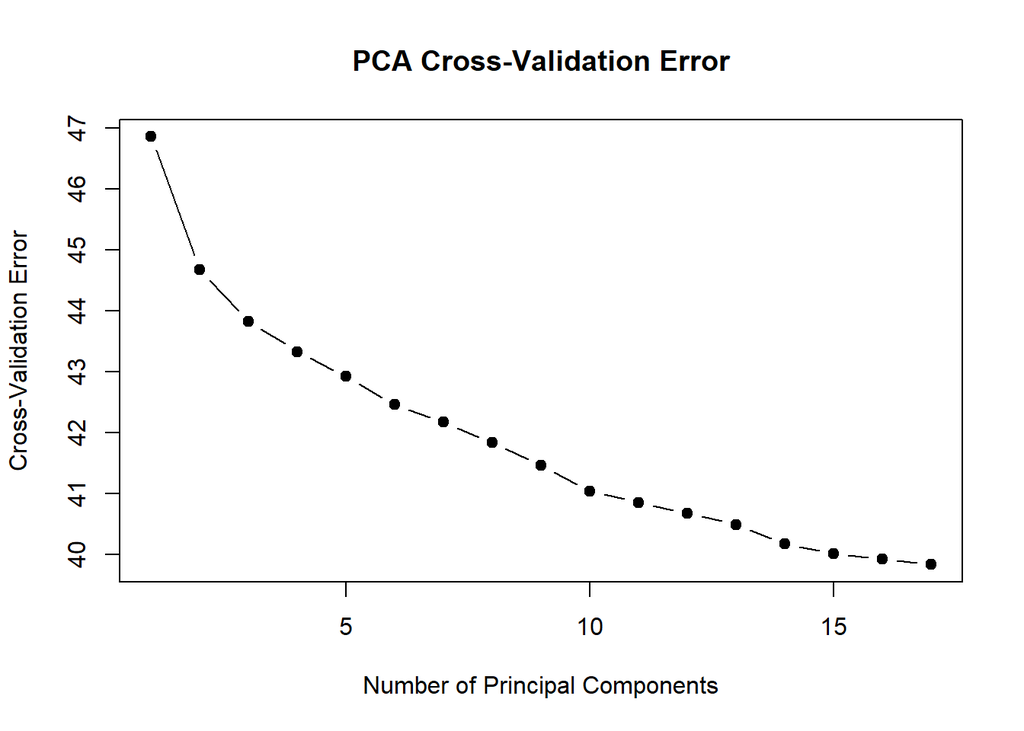

```r
plot(1:17, cv_errors, type = "b", pch = 19,
     xlab = "Number of Principal Components",
     ylab = "Cross-Validation Error",
     main = "PCA Cross-Validation Error")
```

```r
optimal_k <- which.min(cv_errors)
cat("Optimal number of principal components based on cross-validation:", optimal_k, "\n")
```

```
## Optimal number of principal components based on cross-validation: 17
```

Thus, the optimal number of principal components based on cross-validation is 17.